# Uncertainty II

STAT 240 - Fall 2025

Robert Sholl

# Interval Estimation

> All models are wrong, but some are useful - George Box

## Point Estimates

- $\bar{x}$, $s^2$, $\hat{\beta_0}$
  - We’ve only calculated these so far
- They’re **all** wrong estimates
  - How do we use a sample mean to infer the population mean?
  - Why did we spend 5 weeks on distributions and probability?

## How old is the universe?

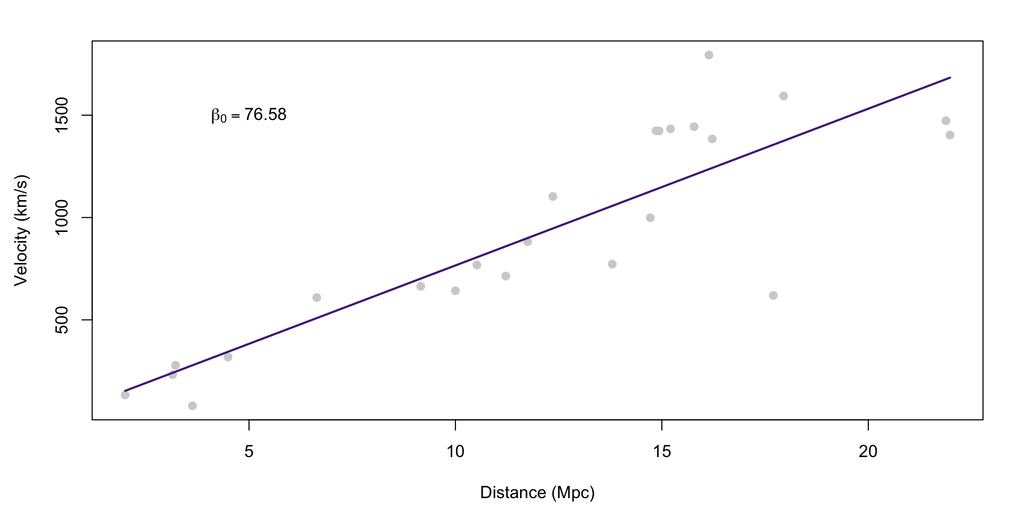

## How old is the universe?

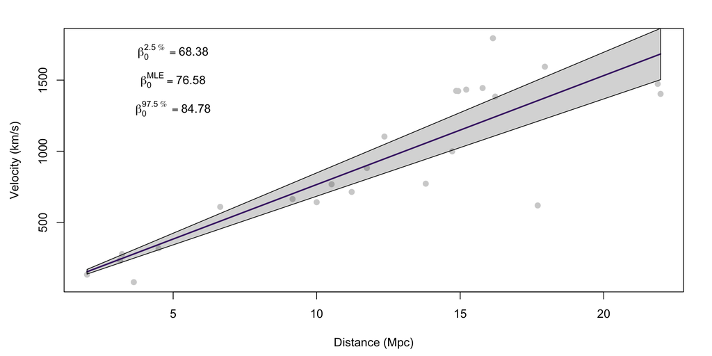

## How old is the universe?

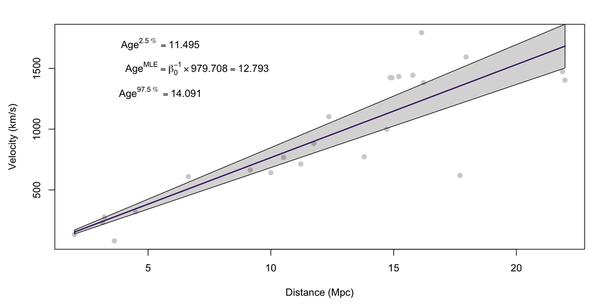

## Frequentist

Methods using the perspective that the probability of an event is defined as the relative frequency of that event’s occurence across *infinite* trials.

- Empirical probability
- “Data driven”
  - Data dependent
- Central Limit Theorem
- Simple in application

## Bayesian

Methods using the perspective that the probability of an event is the result of comparing the likelihood and prior knowledge of the event with the observed evidence.

- Prior knowledge
- “Assumption driven”
  - Open to assumptions
- Horrendous in application

## Linear Regression

- Frequentist:

$$\begin{aligned}
y = \beta_0 + \beta_1x +\epsilon \\
\epsilon \sim N(0,\sigma^2)
\end{aligned}$$

- Since $\mathbb{E}(\epsilon) = 0$:

$$y \sim N(\beta_0+\beta_1x,\sigma^2)$$

## Linear Regression

- Bayesian model:

$$\begin{aligned}
y \sim N(\beta_0+\beta_1x,\sigma^2) \\
\beta_0 \sim N(0,\sigma^2_{\beta_0}) \\
\beta_1 \sim N(0,\sigma^2_{\beta_1}) \\
\sigma^2 \sim \text{inv-Gamma}(q,r)
\end{aligned}$$

## Bayes’ Rule

$$\text{Posterior}\ = \ \frac{\text{Likelihood} \times \text{Prior}}{\text{Evidence}}$$

$$P(A|B)=\frac{P(B|A)P(A)}{P(B|A)P(A)+P(B|A^c)P(A^c)}$$

## Interpreting Intervals

- Confidence Intervals
  - Frequentist
  - “the probability the method is going to produce the correct result.”
- Credible Intervals
  - Bayesian
  - “the probability that the estimate is the truth.”

# Applying Distribution Theory

## Sampling Distributions

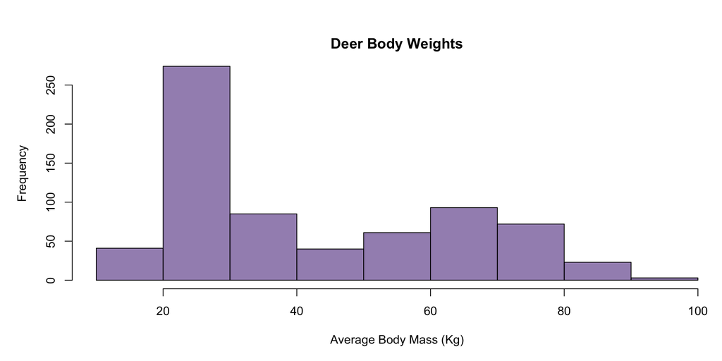

## Sampling Distributions

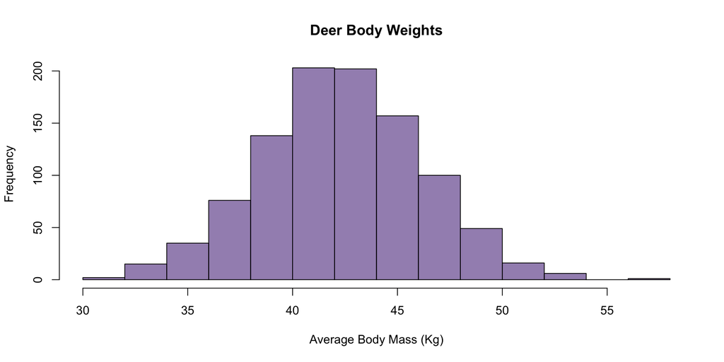

## Intervals

> Given $\bar{x} = 53.17$, $s=17.127$, and $n=10$, calculate the $95\%$ interval of deer body weights.

$95\%$ z-interval:
$$P(-z_0 < Z < z_0)=\ 0.95$$

## Intervals

$$\bar{x} \sim N(\mu,\frac{\sigma^2}{n})$$

- We need population parameters to proceed
  - How can we get rid of them? Fix the distribution to $N(0,1)$?
- What could we do to fix a non-standard normal distribution?

## Intervals

$$z = \frac{x - \mu}{\sigma}$$

- This still needs population parameters

## Pivots

**Pivotal Quantity (Pivot)**: Any function who’s probability distribution does not rely of the population parameters of a given random variable.

$$t^*= \frac{x-\bar x}{s / \sqrt n}$$

- We can “free” the statistic from the population
- Then inference can come exclusively from samples

## t-Distribution

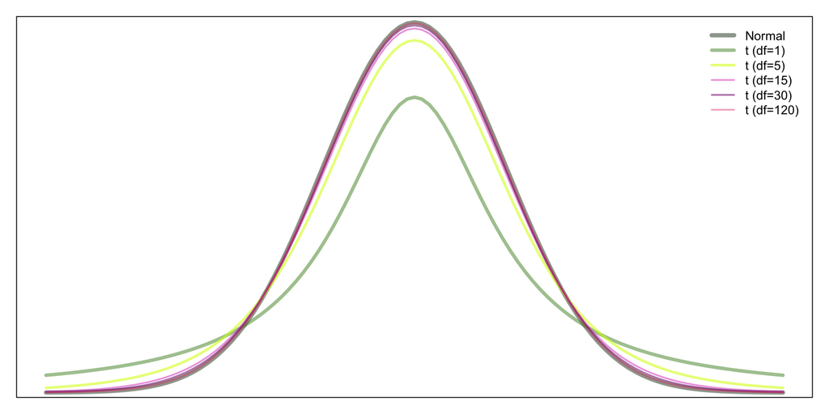

## t-Pivot

$$T=\frac{\bar x - \mu}{s / \sqrt n}$$

$$P(-t_0 < T < t_0)=\ 0.95$$

$$\begin{aligned}
P(-t_0 < T < t_0) =\ 0.95 \\
P(-t_0 < \frac{\bar x-\mu}{s / \sqrt n} < t_0) =\ 0.95 \\
P(-t_0 \ \frac{s}{\sqrt n} < \bar x-\mu < t_0 \ \frac{s}{\sqrt n}) =\ 0.95 \\
P(\bar x-t_0 \ \frac{s}{\sqrt n} < \mu < \bar x+t_0 \ \frac{s}{\sqrt n}) =\ 0.95 \\
\end{aligned}$$

## Confidence Intervals

$$\begin{aligned}
0.99= & \ 1-\alpha \\
\\
\alpha= & \ 0.01 \\
\\
\alpha/2 = & 0.005
\end{aligned}$$

$$\bar x \pm t_{\alpha/2} \ \frac{s}{\sqrt n}$$

## Confidence Intervals

$$\begin{aligned}
\text{Point estimate} & = \bar x \\
\\
\text{Margin of error} & = t_{\alpha/2} \ \frac{s}{\sqrt n} \\
\end{aligned}$$

$$\text{Point estimate} \pm \text{Margin of error}$$

## t-table

| df | 0.500 | 0.250 | 0.200 | 0.150 | 0.100 | 0.050 | 0.025 | 0.010 | 0.001 |
| --- | --- | --- | --- | --- | --- | --- | --- | --- | --- |
| 7 | 0.000 | 0.711 | 0.896 | 1.119 | 1.415 | 1.895 | 2.365 | 2.998 | 4.785 |
| 8 | 0.000 | 0.706 | 0.889 | 1.108 | 1.397 | 1.860 | 2.306 | 2.896 | 4.501 |
| 9 | 0.000 | 0.703 | 0.883 | 1.100 | 1.383 | 1.833 | **2.262** | 2.821 | 4.297 |
| 10 | 0.000 | 0.700 | 0.879 | 1.093 | 1.372 | 1.812 | 2.228 | 2.764 | 4.144 |

## Sample Mean Intervals

$$\begin{aligned}
\text{CI}\ =& \ \bar x \pm t_{\alpha/2} \ \frac{s}{\sqrt n}\\
\\
\text{CI}\ =& \ 53.17 \pm 2.262 \times \frac{17.127}{\sqrt{10}}\\
\\
\text{CI}\ =& \ 53.17 \pm 12.25107 \\
\\
\text{CI}\ =& \ \begin{cases}
53.17 - 12.25107 = 40.91893\\
53.17 + 12.25107 = 65.42107
\end{cases}\\
\\
\text{CI} \ =& \ (40.92,65.42)
\end{aligned}$$